# Practical Machine Learning: Final Project

> Using devices such as Jawbone Up, Nike FuelBand, and Fitbit, it is now possible to collect a large amount of data about personal activity relatively inexpensively. These type of devices are part of the quantified self movement—a group of enthusiasts who take measurements about themselves regularly to improve their health, to find patterns in their behavior, or because they are tech geeks. One thing that people regularly do is quantify how much of a particular activity they do, but they rarely quantify how well they do it.

> In this project, I use data from accelerometers on the belt, forearm, arm, and dumbell of 6 participants who were asked to perform barbell lifts correctly and incorrectly in 5 different ways. The goal is to predict the manner in which they did the exercise. This is the “classe” variable in the training set. The following report details the model utilized, cross validation, expected out of sample error, and the basis for various choices.

### Load library packages

```r
library(tidyverse)
library(caret)
library(parallel)
library(doParallel)
```

### Load the full training data set

```r
# Read file
df <- read_csv("Downloads/pml-training.csv")
```

### Basic Exploratory Data Analysis (EDA)

```r
# Review first 10 observations to get a sense of the data
head(df, n=10)
```

| ...1 | user_name | raw_timestamp_part_1 | raw_timestamp_part_2 | cvtd_timestamp | new_window | num_window | roll_belt | pitch_belt | yaw_belt | total_accel_belt | kurtosis_roll_belt | kurtosis_picth_belt | kurtosis_yaw_belt | skewness_roll_belt | skewness_roll_belt.1 | skewness_yaw_belt | max_roll_belt | max_picth_belt | max_yaw_belt | min_roll_belt | min_pitch_belt | min_yaw_belt | amplitude_roll_belt | amplitude_pitch_belt | amplitude_yaw_belt | var_total_accel_belt | avg_roll_belt | stddev_roll_belt | var_roll_belt | … |
| --- | --- | --- | --- | --- | --- | --- | --- | --- | --- | --- | --- | --- | --- | --- | --- | --- | --- | --- | --- | --- | --- | --- | --- | --- | --- | --- | --- | --- | --- | --- |
| 1 | carlitos | 1323084231 | 788290 | 05/12/2011 11:23 | no | 11 | 1.41 | 8.07 | -94.4 | 3 | NA | NA | NA | NA | NA | NA | NA | NA | NA | NA | NA | NA | NA | NA | NA | NA | NA | NA | NA | … |
| 2 | carlitos | 1323084231 | 808298 | 05/12/2011 11:23 | no | 11 | 1.41 | 8.07 | -94.4 | 3 | NA | NA | NA | NA | NA | NA | NA | NA | NA | NA | NA | NA | NA | NA | NA | NA | NA | NA | NA | … |
| 3 | carlitos | 1323084231 | 820366 | 05/12/2011 11:23 | no | 11 | 1.42 | 8.07 | -94.4 | 3 | NA | NA | NA | NA | NA | NA | NA | NA | NA | NA | NA | NA | NA | NA | NA | NA | NA | NA | NA | … |
| 4 | carlitos | 1323084232 | 120339 | 05/12/2011 11:23 | no | 12 | 1.48 | 8.05 | -94.4 | 3 | NA | NA | NA | NA | NA | NA | NA | NA | NA | NA | NA | NA | NA | NA | NA | NA | NA | NA | NA | … |
| 5 | carlitos | 1323084232 | 196328 | 05/12/2011 11:23 | no | 12 | 1.48 | 8.07 | -94.4 | 3 | NA | NA | NA | NA | NA | NA | NA | NA | NA | NA | NA | NA | NA | NA | NA | NA | NA | NA | NA | … |
| 6 | carlitos | 1323084232 | 304277 | 05/12/2011 11:23 | no | 12 | 1.45 | 8.06 | -94.4 | 3 | NA | NA | NA | NA | NA | NA | NA | NA | NA | NA | NA | NA | NA | NA | NA | NA | NA | NA | NA | … |
| 7 | carlitos | 1323084232 | 368296 | 05/12/2011 11:23 | no | 12 | 1.42 | 8.09 | -94.4 | 3 | NA | NA | NA | NA | NA | NA | NA | NA | NA | NA | NA | NA | NA | NA | NA | NA | NA | NA | NA | … |
| 8 | carlitos | 1323084232 | 440390 | 05/12/2011 11:23 | no | 12 | 1.42 | 8.13 | -94.4 | 3 | NA | NA | NA | NA | NA | NA | NA | NA | NA | NA | NA | NA | NA | NA | NA | NA | NA | NA | NA | … |
| 9 | carlitos | 1323084232 | 484323 | 05/12/2011 11:23 | no | 12 | 1.43 | 8.16 | -94.4 | 3 | NA | NA | NA | NA | NA | NA | NA | NA | NA | NA | NA | NA | NA | NA | NA | NA | NA | NA | NA | … |
| 10 | carlitos | 1323084232 | 484434 | 05/12/2011 11:23 | no | 12 | 1.45 | 8.17 | -94.4 | 3 | NA | NA | NA | NA | NA | NA | NA | NA | NA | NA | NA | NA | NA | NA | NA | NA | NA | NA | NA | … |

> The entry id (column 1), all timestamp factors, the new_window and num_window will not provide any predictive power and could impact model accuracy. I will keep the user names because I looked ahead at the testing set and see that the same names are used in testing so this model can take advantage of individual user nuances.

> There are many columns with only NAs in the first team. I need to explore this further.

```r
# Check for number of NAs in each column/predictor
summary(is.na(df))
```

```
##     ...1         user_name       raw_timestamp_part_1 raw_timestamp_part_2
##  Mode :logical   Mode :logical   Mode :logical        Mode :logical
##  FALSE:19622     FALSE:19622     FALSE:19622          FALSE:19622
##
##  cvtd_timestamp  new_window      num_window      roll_belt
##  Mode :logical   Mode :logical   Mode :logical   Mode :logical
##  FALSE:19622     FALSE:19622     FALSE:19622     FALSE:19622
##
##  pitch_belt       yaw_belt       total_accel_belt kurtosis_roll_belt
##  Mode :logical   Mode :logical   Mode :logical    Mode :logical
##  FALSE:19622     FALSE:19622     FALSE:19622      FALSE:406
##                                                   TRUE :19216
##  kurtosis_picth_belt kurtosis_yaw_belt skewness_roll_belt skewness_roll_belt.1
##  Mode :logical       Mode :logical     Mode :logical      Mode :logical
##  FALSE:406           FALSE:406         FALSE:397          FALSE:406
##  TRUE :19216         TRUE :19216       TRUE :19225        TRUE :19216
##  skewness_yaw_belt max_roll_belt   max_picth_belt  max_yaw_belt
##  Mode :logical     Mode :logical   Mode :logical   Mode :logical
##  FALSE:406         FALSE:406       FALSE:406       FALSE:406
##  TRUE :19216       TRUE :19216     TRUE :19216     TRUE :19216
##  min_roll_belt   min_pitch_belt  min_yaw_belt    amplitude_roll_belt
##  Mode :logical   Mode :logical   Mode :logical   Mode :logical
##  FALSE:406       FALSE:406       FALSE:406       FALSE:406
##  TRUE :19216     TRUE :19216     TRUE :19216     TRUE :19216
##  amplitude_pitch_belt amplitude_yaw_belt var_total_accel_belt avg_roll_belt
##  Mode :logical        Mode :logical      Mode :logical        Mode :logical
##  FALSE:406            FALSE:406          FALSE:406            FALSE:406
##  TRUE :19216          TRUE :19216        TRUE :19216          TRUE :19216
##  stddev_roll_belt var_roll_belt   avg_pitch_belt  stddev_pitch_belt
##  Mode :logical    Mode :logical   Mode :logical   Mode :logical
##  FALSE:406        FALSE:406       FALSE:406       FALSE:406
##  TRUE :19216      TRUE :19216     TRUE :19216     TRUE :19216
##  var_pitch_belt  avg_yaw_belt    stddev_yaw_belt var_yaw_belt
##  Mode :logical   Mode :logical   Mode :logical   Mode :logical
##  FALSE:406       FALSE:406       FALSE:406       FALSE:406
##  TRUE :19216     TRUE :19216     TRUE :19216     TRUE :19216
##  gyros_belt_x    gyros_belt_y    gyros_belt_z    accel_belt_x
##  Mode :logical   Mode :logical   Mode :logical   Mode :logical
##  FALSE:19622     FALSE:19622     FALSE:19622     FALSE:19622
##
```

[output cut: 109 more lines]

```
##  Mode :logical     Mode :logical        Mode :logical     Mode :logical
##  FALSE:406         FALSE:406            FALSE:406         FALSE:406
##  TRUE :19216       TRUE :19216          TRUE :19216       TRUE :19216
##  stddev_yaw_forearm var_yaw_forearm gyros_forearm_x gyros_forearm_y
##  Mode :logical      Mode :logical   Mode :logical   Mode :logical
##  FALSE:406          FALSE:406       FALSE:19622     FALSE:19622
##  TRUE :19216        TRUE :19216
##  gyros_forearm_z accel_forearm_x accel_forearm_y accel_forearm_z
##  Mode :logical   Mode :logical   Mode :logical   Mode :logical
##  FALSE:19622     FALSE:19622     FALSE:19622     FALSE:19622
##
##  magnet_forearm_x magnet_forearm_y magnet_forearm_z   classe
##  Mode :logical    Mode :logical    Mode :logical    Mode :logical
##  FALSE:19622      FALSE:19622      FALSE:19622      FALSE:19622
##
```

> Columns either have zero NAs (FALSE:19622, which is complete data), all NAs (TRUE: 19622, which is empty data), or nearly all NAs (TRUE: 19216). There is no clean way of imputing that level of missing data so I will remove any column with missing data (NAs).

### Data wrangling

```r
# Remove all columns with NAs
df <- df %>% select_if(~ !any(is.na(.)))

# Remove irrelevant factors
df <- df %>%
    select(-c("...1", "raw_timestamp_part_1", "raw_timestamp_part_2",
              "cvtd_timestamp", "new_window", "num_window"))

# Make response and user_name factors
df$classe <- as.factor(df$classe)
df$user_name <- as.factor(df$user_name)

# Show new dimensions
dim(df)
```

```
## [1] 19622    54
```

### Split data into training/validation and holdout/testing sets

```r
set.seed(977086)
trainIndex <- createDataPartition(df$classe, p = 0.8, list = FALSE)
training <- df[trainIndex,] # 80%
holdout <- df[-trainIndex,] # 20% -- plenty for large data set
```

### Create a common 10-fold CV training control for tuning & model comparison

```r
# Create common folds for 10-fold cross validation model comparisons
commonFolds <- createFolds(training$classe, k=10)
commonTrainControl <- trainControl(method = "cv",
                                   index = commonFolds,
                                   verboseIter = FALSE,
                                   allowParallel = TRUE)
```

### Enable parallel processing to train larger models

```r
cluster <- makeCluster(detectCores() - 1)
registerDoParallel(cluster)
```

### Train 4 different models

```r
# Extreme Gradient Boosting Trees
set.seed(977086)
modelXGB <- train(classe ~ .,
                 data = training,
                 method = "xgbTree",
                 trControl = commonTrainControl,
                 verbose = FALSE)
```

```r
# Random Forest
set.seed(977086)
modelRF <- train(classe ~ .,
                 data = training,
                 method = "rf",
                 trControl = commonTrainControl,
                 verbose = FALSE)
```

```r
# Stochastic Gradient Boosting
set.seed(977086)
modelGBM <- train(classe ~ .,
                 data = training,
                 method = "gbm",
                 trControl = commonTrainControl,
                 verbose = FALSE)
```

```r
# K-Nearest Neighbors
set.seed(977086)
modelKNN <- train(classe ~ .,
                 data = training,
                 method = "kknn",
                 trControl = commonTrainControl,
                 preProcess = c("center", "scale"),
                 verbose = FALSE)
```

### Display model training results

```r
modelXGB
```

```
## eXtreme Gradient Boosting
##
## 15699 samples
##    53 predictor
##     5 classes: 'A', 'B', 'C', 'D', 'E'
##
## No pre-processing
## Resampling: Cross-Validated (10 fold)
## Summary of sample sizes: 1571, 1570, 1569, 1571, 1569, 1570, ...
## Resampling results across tuning parameters:
##
##   eta  max_depth  colsample_bytree  subsample  nrounds  Accuracy   Kappa
##   0.3  1          0.6               0.50        50      0.7774308  0.7178529
##   0.3  1          0.6               0.50       100      0.8392323  0.7964640
##   0.3  1          0.6               0.50       150      0.8682433  0.8331672
##   0.3  1          0.6               0.75        50      0.7769143  0.7173031
##   0.3  1          0.6               0.75       100      0.8402869  0.7978492
##   0.3  1          0.6               0.75       150      0.8675286  0.8323125
##   0.3  1          0.6               1.00        50      0.7768928  0.7172135
##   0.3  1          0.6               1.00       100      0.8360051  0.7924133
##   0.3  1          0.6               1.00       150      0.8632892  0.8269691
##   0.3  1          0.8               0.50        50      0.7815357  0.7232000
##   0.3  1          0.8               0.50       100      0.8409027  0.7985331
##   0.3  1          0.8               0.50       150      0.8678824  0.8327294
##   0.3  1          0.8               0.75        50      0.7779262  0.7185571
##   0.3  1          0.8               0.75       100      0.8422050  0.8002281
##   0.3  1          0.8               0.75       150      0.8691140  0.8342958
##   0.3  1          0.8               1.00        50      0.7770060  0.7173414
##   0.3  1          0.8               1.00       100      0.8361750  0.7926428
##   0.3  1          0.8               1.00       150      0.8637492  0.8275584
##   0.3  2          0.6               0.50        50      0.8858596  0.8554845
##   0.3  2          0.6               0.50       100      0.9204407  0.8993151
##   0.3  2          0.6               0.50       150      0.9324160  0.9144758
##   0.3  2          0.6               0.75        50      0.8912316  0.8623049
##   0.3  2          0.6               0.75       100      0.9250342  0.9051361
##   0.3  2          0.6               0.75       150      0.9363583  0.9194763
##   0.3  2          0.6               1.00        50      0.8906372  0.8615829
##   0.3  2          0.6               1.00       100      0.9223517  0.9017441
##   0.3  2          0.6               1.00       150      0.9336971  0.9161111
##   0.3  2          0.8               0.50        50      0.8885491  0.8588851
```

[output cut: 73 more lines]

```
##   0.4  3          0.8               0.50       150      0.9436340  0.9286781
##   0.4  3          0.8               0.75        50      0.9370661  0.9203577
##   0.4  3          0.8               0.75       100      0.9475197  0.9335970
##   0.4  3          0.8               0.75       150      0.9487300  0.9351275
##   0.4  3          0.8               1.00        50      0.9373845  0.9207701
##   0.4  3          0.8               1.00       100      0.9486379  0.9350160
##   0.4  3          0.8               1.00       150      0.9503224  0.9371439
##
## Tuning parameter 'gamma' was held constant at a value of 0
## Tuning
##  parameter 'min_child_weight' was held constant at a value of 1
## Accuracy was used to select the optimal model using the largest value.
## The final values used for the model were nrounds = 150, max_depth = 3, eta
##  = 0.4, gamma = 0, colsample_bytree = 0.6, min_child_weight = 1 and subsample
##  = 1.
```

```r
confusionMatrix(predict(modelXGB, holdout), holdout$classe)
```

```
## Confusion Matrix and Statistics
##
##           Reference
## Prediction    A    B    C    D    E
##          A 1116    0    0    0    0
##          B    0  757    6    0    0
##          C    0    2  678    7    2
##          D    0    0    0  635    2
##          E    0    0    0    1  717
##
## Overall Statistics
##
##                Accuracy : 0.9949
##                  95% CI : (0.9921, 0.9969)
##     No Information Rate : 0.2845
##     P-Value [Acc > NIR] : < 2.2e-16
##
##                   Kappa : 0.9936
##
##  Mcnemar's Test P-Value : NA
##
## Statistics by Class:
##
##                      Class: A Class: B Class: C Class: D Class: E
## Sensitivity            1.0000   0.9974   0.9912   0.9876   0.9945
## Specificity            1.0000   0.9981   0.9966   0.9994   0.9997
## Pos Pred Value         1.0000   0.9921   0.9840   0.9969   0.9986
## Neg Pred Value         1.0000   0.9994   0.9981   0.9976   0.9988
## Prevalence             0.2845   0.1935   0.1744   0.1639   0.1838
## Detection Rate         0.2845   0.1930   0.1728   0.1619   0.1828
## Detection Prevalence   0.2845   0.1945   0.1756   0.1624   0.1830
## Balanced Accuracy      1.0000   0.9977   0.9939   0.9935   0.9971
```

```r
modelRF
```

```
## Random Forest
##
## 15699 samples
##    53 predictor
##     5 classes: 'A', 'B', 'C', 'D', 'E'
##
## No pre-processing
## Resampling: Cross-Validated (10 fold)
## Summary of sample sizes: 1571, 1570, 1569, 1571, 1569, 1570, ...
## Resampling results across tuning parameters:
##
##   mtry  Accuracy   Kappa
##    2    0.9317507  0.9135675
##   29    0.9381278  0.9216674
##   57    0.9289976  0.9101198
##
## Accuracy was used to select the optimal model using the largest value.
## The final value used for the model was mtry = 29.
```

```r
confusionMatrix(predict(modelRF, holdout), holdout$classe)
```

```
## Confusion Matrix and Statistics
##
##           Reference
## Prediction    A    B    C    D    E
##          A 1116    4    0    0    0
##          B    0  754    5    0    1
##          C    0    1  679   13    3
##          D    0    0    0  628    1
##          E    0    0    0    2  716
##
## Overall Statistics
##
##                Accuracy : 0.9924
##                  95% CI : (0.9891, 0.9948)
##     No Information Rate : 0.2845
##     P-Value [Acc > NIR] : < 2.2e-16
##
##                   Kappa : 0.9903
##
##  Mcnemar's Test P-Value : NA
##
## Statistics by Class:
##
##                      Class: A Class: B Class: C Class: D Class: E
## Sensitivity            1.0000   0.9934   0.9927   0.9767   0.9931
## Specificity            0.9986   0.9981   0.9948   0.9997   0.9994
## Pos Pred Value         0.9964   0.9921   0.9756   0.9984   0.9972
## Neg Pred Value         1.0000   0.9984   0.9985   0.9954   0.9984
## Prevalence             0.2845   0.1935   0.1744   0.1639   0.1838
## Detection Rate         0.2845   0.1922   0.1731   0.1601   0.1825
## Detection Prevalence   0.2855   0.1937   0.1774   0.1603   0.1830
## Balanced Accuracy      0.9993   0.9958   0.9937   0.9882   0.9962
```

```r
modelGBM
```

```
## Stochastic Gradient Boosting
##
## 15699 samples
##    53 predictor
##     5 classes: 'A', 'B', 'C', 'D', 'E'
##
## No pre-processing
## Resampling: Cross-Validated (10 fold)
## Summary of sample sizes: 1571, 1570, 1569, 1571, 1569, 1570, ...
## Resampling results across tuning parameters:
##
##   interaction.depth  n.trees  Accuracy   Kappa
##   1                   50      0.7357579  0.6648544
##   1                  100      0.7976798  0.7437811
##   1                  150      0.8285665  0.7829115
##   2                   50      0.8267475  0.7804854
##   2                  100      0.8767225  0.8439574
##   2                  150      0.8994132  0.8727079
##   3                   50      0.8675569  0.8322851
##   3                  100      0.9065050  0.8816583
##   3                  150      0.9202143  0.8990379
##
## Tuning parameter 'shrinkage' was held constant at a value of 0.1
##
## Tuning parameter 'n.minobsinnode' was held constant at a value of 10
## Accuracy was used to select the optimal model using the largest value.
## The final values used for the model were n.trees = 150, interaction.depth =
##  3, shrinkage = 0.1 and n.minobsinnode = 10.
```

```r
confusionMatrix(predict(modelGBM, holdout), holdout$classe)
```

```
## Confusion Matrix and Statistics
##
##           Reference
## Prediction    A    B    C    D    E
##          A 1100   32    0    2    0
##          B   12  706   20    3    8
##          C    4   20  652   25    6
##          D    0    1   11  609   10
##          E    0    0    1    4  697
##
## Overall Statistics
##
##                Accuracy : 0.9595
##                  95% CI : (0.9528, 0.9654)
##     No Information Rate : 0.2845
##     P-Value [Acc > NIR] : < 2.2e-16
##
##                   Kappa : 0.9487
##
##  Mcnemar's Test P-Value : NA
##
## Statistics by Class:
##
##                      Class: A Class: B Class: C Class: D Class: E
## Sensitivity            0.9857   0.9302   0.9532   0.9471   0.9667
## Specificity            0.9879   0.9864   0.9830   0.9933   0.9984
## Pos Pred Value         0.9700   0.9426   0.9222   0.9651   0.9929
## Neg Pred Value         0.9943   0.9833   0.9900   0.9897   0.9925
## Prevalence             0.2845   0.1935   0.1744   0.1639   0.1838
## Detection Rate         0.2804   0.1800   0.1662   0.1552   0.1777
## Detection Prevalence   0.2891   0.1909   0.1802   0.1608   0.1789
## Balanced Accuracy      0.9868   0.9583   0.9681   0.9702   0.9826
```

```r
modelKNN
```

```
## k-Nearest Neighbors
##
## 15699 samples
##    53 predictor
##     5 classes: 'A', 'B', 'C', 'D', 'E'
##
## Pre-processing: centered (57), scaled (57)
## Resampling: Cross-Validated (10 fold)
## Summary of sample sizes: 1571, 1570, 1569, 1571, 1569, 1570, ...
## Resampling results across tuning parameters:
##
##   kmax  Accuracy   Kappa
##   5     0.8597435  0.8225451
##   7     0.8597435  0.8225451
##   9     0.8597435  0.8225451
##
## Tuning parameter 'distance' was held constant at a value of 2
## Tuning
##  parameter 'kernel' was held constant at a value of optimal
## Accuracy was used to select the optimal model using the largest value.
## The final values used for the model were kmax = 9, distance = 2 and kernel
##  = optimal.
```

```r
confusionMatrix(predict(modelKNN, holdout), holdout$classe)
```

```
## Confusion Matrix and Statistics
##
##           Reference
## Prediction    A    B    C    D    E
##          A 1112    4    1    0    0
##          B    3  746    2    0    2
##          C    1    7  677    4    1
##          D    0    1    4  636    1
##          E    0    1    0    3  717
##
## Overall Statistics
##
##                Accuracy : 0.9911
##                  95% CI : (0.9876, 0.9938)
##     No Information Rate : 0.2845
##     P-Value [Acc > NIR] : < 2.2e-16
##
##                   Kappa : 0.9887
##
##  Mcnemar's Test P-Value : NA
##
## Statistics by Class:
##
##                      Class: A Class: B Class: C Class: D Class: E
## Sensitivity            0.9964   0.9829   0.9898   0.9891   0.9945
## Specificity            0.9982   0.9978   0.9960   0.9982   0.9988
## Pos Pred Value         0.9955   0.9907   0.9812   0.9907   0.9945
## Neg Pred Value         0.9986   0.9959   0.9978   0.9979   0.9988
## Prevalence             0.2845   0.1935   0.1744   0.1639   0.1838
## Detection Rate         0.2835   0.1902   0.1726   0.1621   0.1828
## Detection Prevalence   0.2847   0.1919   0.1759   0.1637   0.1838
## Balanced Accuracy      0.9973   0.9903   0.9929   0.9936   0.9966
```

### Compare the model results via resampling

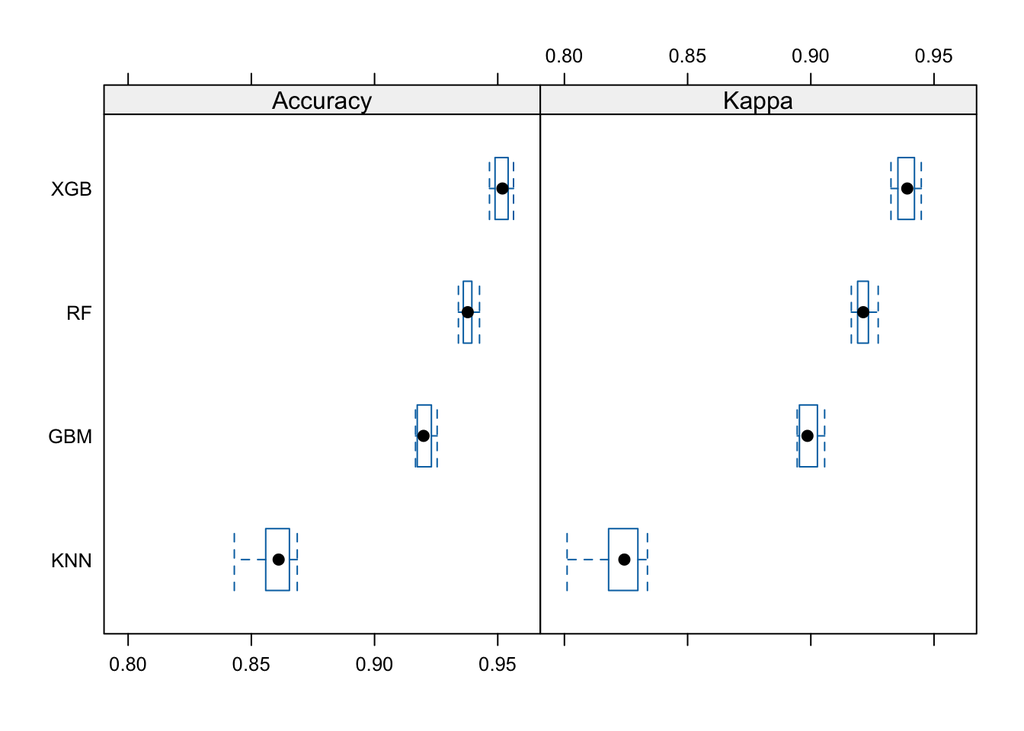

```r
results <- resamples(list(XGB=modelXGB, RF=modelRF, GBM=modelGBM, KNN=modelKNN))
bwplot(results)
```

> A resampling comparison shows that the Extreme Gradient Boosting Tree (XGBTree) model produces the best expected accuracy and kappa so I will retrain that model on ALL training data, including the holdout data prior to using the model to make quiz predictions.

### Retrain selected model on all training data

```r
# Combine training and holdout sets for final training
final_training <- training %>% bind_rows(holdout)

# Use tuning from previous CV tuning
set.seed(977086)
modelXGB_Final <- train(classe ~ .,
                        data = final_training,
                        method = "xgbTree",
                        tuneGrid = data.frame(modelXGB$bestTune),
                        verbose = FALSE)
```

### Load and shape final testing set prior to making predictions for quiz submission

```r
quiz <- read_csv("~/Downloads/pml-testing.csv")
```

### Quiz results (not shown for academic integrity – 100% obtained on quiz)

```r
final_answers <- data.frame(quiz$problem_id, predict(modelXGB_Final, quiz))
```

### Stop parallel processing

```r
stopCluster(cluster)
```